# Algorithm Class 10 - Lecture 5

Binary Tree & Binary Search Tree

June/7/2019

# 1 Binary Tree

Definition: at most two children node.

## 1.1 Example

```
      10 == root
    /    \
  5       15
 / \     /  \
2   7   12  20   <- all leaf node's level == 3
```

## 1.2 Implementation

```java
class TreeNode {
  int value;
  // int counter;
  TreeNode left;
  TreeNode right;
  // TreeNode parent; point to this node's parent node.
}
```

## 1.3 Tree Traversal

```
           10
         /    \
       5       15
      / \     /  \
     2   7   12  20
   /   \
null   null
```

### 1.3.1 Pre-Order

Output: 10, 5, 2, 7, 15, 12, 20

```
(10) -> (5) -> (2) -> null (left) -> 2 -> null (right) -> 5 -> (7) -> null -> 7 -> null -> 7 -> 5 -> 10 -> (15) -> (12) -> null -> 12 -> null -> 12 -> 15 -> (20) -> null -> 20 -> null -> 20 -> 15 -> 10
```

Print or change the value of myself, then left and right.

```java
void preOrder(TreeNode root) {
  if (root = null) {
    return;
  }
  System.out.println(root.value);
  preOrder(root.left);
  preOrder(root.right);
}
```

### 1.3.2 In-Order

Output: 2, 5, 7, 10, 12, 15, 20

```
10 -> 5 -> 2 -> null -> (2) -> null -> 2 -> (5) -> 7 -> null -> (7) -> null -> 7 -> 5 -> (10) -> 15 -> 12 -> null -> (12) -> null -> 12 -> (15) -> 20 -> null -> (20) -> null -> 20 -> 15 -> 10
```

```java
void inOrder(TreeNode root) {
  if (root = null) {
    return;
  }
  inOrder(root.left);
  System.out.println(root.value);
  inOrder(root.right);
}
```

### 1.3.3 Post-Order

Output: 2, 7, 5, 12, 20, 15, 10

```
10 -> 5 -> 2 -> null -> 2 -> null -> (2) -> 5 -> 7 -> null -> 7 -> null -> (7) -> (5) -> 10 -> 15 -> 12 -> null -> 12 -> null -> (12) -> 15 -> 20 -> null -> 20 -> null -> (20) -> (15) -> (10)
```

```java
void postOrder(TreeNode root) {
  if (root = null) {
    return;
  }
  postOrder(root.left);
  postOrder(root.right);
  System.out.println(root.value);
}
```

### 1.3.4 Trick

**Base case** usually refers to the null ChildNode below the leaf node.

## 1.4 Basic Concept of Binary Tree

### 1.4.1 Balanced Binary Tree

**Balanced binary tree** is commonly defined as a binary tree in which the depth of the left and right subtrees of **every node** differ by 1 or less.

```
       10
    /      \
  5          15
 / \        /  \
2  null  null  null
```

**Conclusion 1:** If a tree has n number of nodes, and it is **balanced**, then the height (level) of the tree is O($\log_2(n)$).

### 1.4.2 Complete Binary Tree

**Complete binary tree** is a binary tree in which every level, except possibly the last, is completely filled, and all nodes are as far left as possible.

```
      10
    /    \
  5        15
 / \      /  \
2   12   20  null
```

**Conclusion 2:** If a tree is a complete tree, then it must be a balanced tree.

### 1.4.3 Binary Search Tree

**Binary search tree**, for every single node in the tree, the values in its left subtree are all smaller than its value, and the values in its right subtree are all larger than its value.

```
      10
    /    \
  5       15
 / \     /  \
2   7   12  20
```

**Conclusion 3:** If we print the value of the nodes in BST in in-order sequence, then it must form an ascending order.

### 1.4.4 Duplicate Values in Binary Tree

What if there are duplicate values? E.g., 10, 10, 5, 5, 5, 15, 2, 7, 12, 20

```
    (10,2)
    /    \
(5,3)   (15,1)
 / \     /  \
2   7   12  20
```

```java
class TreeNode {
  int value;
  int counter;
  TreeNode left;
  TreeNode right;
}
```

## 1.5 Discussion (High Level)

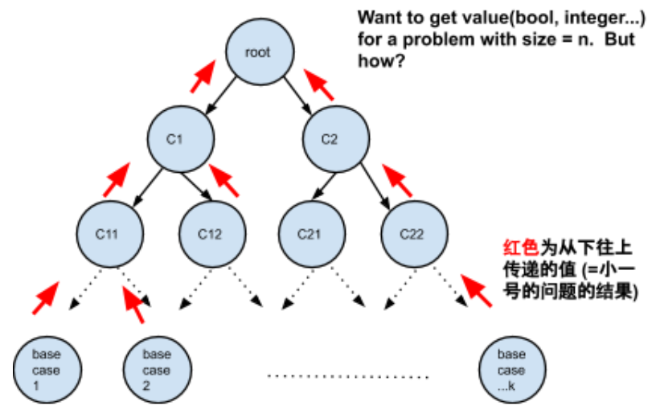

- Binary trees are often the most common type of interview topic that is most closely integrated with recursion.
- Reason:
  - The properties of the nodes of each layer are consistent with those properties of the next layer. It is easy to define **recursive rule**.
  - **Base case** (generally): null pointer under the leaf node
  - Example 1: `int getHeight(Node root)`
  - Example 2: Count the number of nodes in a tree.
- Fundamental Knowledge:
  - Traversal of a binary tree
  - Definition
    - Balanced binary tree
    - Complete binary tree
    - Binary search tree (BST)

### 1.5.1 `getHeight()`

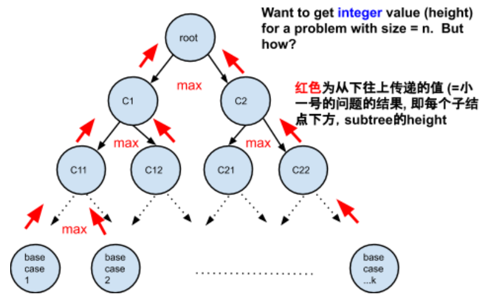

```java
int getHeight(TreeNode root) {
  // Base case
  if (root == null) {
    return 0;
  }

  // Step 1
  int leftHeight = getHeight(root.left);
  int rightHeight = getHeight(root.right);

  // Step 2
  int myHeight = Math.max(leftHeight, rightHeight) + 1;

  // Step 3
  return myHeight;
}
```

- Time: O($n$), n is the total number of nodes in the tree
- Space: worst case O($n$), or O($\text{height}$)

## 1.6 Problem 1: Whether a Balanced Binary Tree? (舉一反一)

How to determine whether a binary tree is a **balanced** binary tree?

This is NOT an optimal solution:

```java
public boolean isBalanced(TreeNode root) {
  // Base case
  if (root == null) {
    return true;
  }

  // Recursion rule
  int leftHeight = getHeight(root.left);
  int rightHeight = getHeight(root.right);
  if (Math.abs(leftHeight - rightHeight) > 1) {
    return false;
  }
  return isBalanced(root.left) && isBalanced(root.right);
}
```

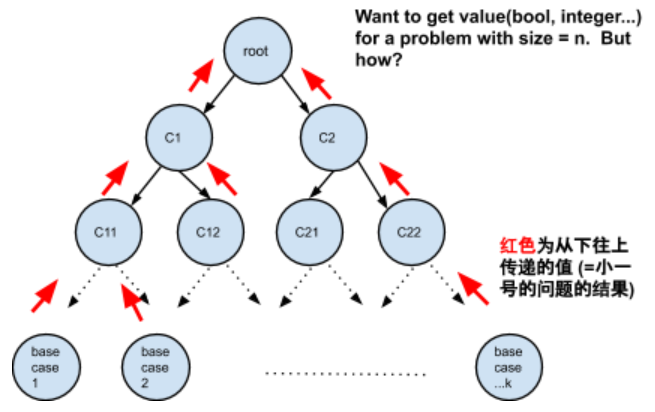

```
                        -----------------------------
                        | isBalanced(root: n nodes) |
                        |getHeight(C1) getHeight(C2)|
                        |     n/2     +     n/2     |
                        -----------------------------
                        Time spent in this node = O(n)                          = n
                              /                \
   -------------------------------          -------------------------------
   |  isBalanced(C1: n/2 nodes)  |          |  isBalanced(C2: n/2 nodes)  |
   |getHeight(C11) getHeight(C12)|    &&    |getHeight(C21) getHeight(C22)|
   |      n/4     +     n/4      |          |      n/4     +     n/4      |
   -------------------------------          -------------------------------
   Time spent in this node = O(n/2)    +    Time spent in this node = O(n/2)    = n
             /         \                              /         \
-----------------   -----------------    -----------------   -----------------
|isBalanced(C11)|   |isBalanced(C12)|    |isBalanced(C21)|   |isBalanced(C22)|
|   n/8 + n/8   |   |   n/8 + n/8   |    |   n/8 + n/8   |   |   n/8 + n/8   |
-----------------   -----------------    -----------------   -----------------
     O(n/4)              O(n/4)               O(n/4)              O(n/4)        = n
   /         \         /         \          /         \         /         \
```

- Height: $\log(n)$ levels
- Each level time: O($n$)
- Total time: O($n\log(n)$)

## 1.7 Problem 2: Whether a Symmetric Binary Tree? (舉一反二)

How to judge whether a binary tree is symmetric?

```
            10
         5a || 5b
      1a 3a || 3b 1b
2a 4a 6a 8a || 8b 6b 4b 2b
```

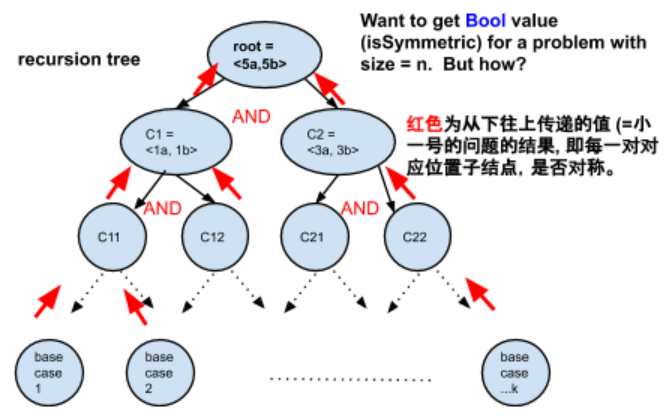

```
                             root = <5a, 5b>
                          /                  \
           C1 = <1a, 1b>           &&           C2 = <3a, 3b>
              /    \                                /    \
(C11 = <2a, 2b> && C12 = <4a, 4b>)    (C21 = <6a, 6b> && C22 = <8a, 8b>)
```

```java
boolean main(TreeNode root) {
  if (root == null) {
    return false;
  }
  return isSymmetric(root.left, root.right);
}

boolean isSymmetric(TreeNode left, TreeNode right) {
  // Both sides are null, which is symmetric, return true
  if (left == null && right == null) {
    return true;
  }
  // Only one side is null, which is not symmetric, return false
  else if (left == null || right == null) {
    return false;
  }
  // The values of two sides are not equal, which is not symmetric, return false
  else if (left.value != right.value) {
    return false;
  }

  return isSymmetric(left.left, right.right) && isSymmetric(left.right, right.left);
}
```

- Time: O($n$)
- Space: O($\text{height}$)

## 1.8 Problem 3: Whether Have Same Structure of Two Binary Trees? (舉一反三)

Let’s assume if we tweak the lchild with rchild of an arbitrary node in a binary tree, then the “structure” of the tree are not changed. Then how can we determine whether two binary trees’ structures are identical.

```
  8
 / \
4   5
7

         Case 1

   8a               8b
 /    \           /    \
4a    5a   AND   4b    5b
|                |
7                7

           OR

         Case 2

   8a               8b
 /    \           /    \
4a    5a   AND   5b    4b
|                       |
7                       7
```

```java
boolean isIdentical(TreeNode left, TreeNode right) {
  if (left == null && right == null) {
    return true;
  }
  else if (left == null || right == null) {
    return false;
  }
  else if (left.value != right.value) {
    return false;
  }

  // (LL && RR) || (LR && RL)
  return (isIdentical(left.left, right.left) && isIdentical(left.right, right.right)) || (isIdentical(left.left, right.right) && isIdentical(left.right, right.left));
}
```

Assume two trees are both balanced:

```
root of given left tree: 8a (n nodes)
root of given right tree: 8b (n nodes)

                  isIdentical(8a, 8b)
           /             |  |             \
(8a.L, 8b.L)  (8a.R, 8b.R)  (8a.L, 8b.R)  (8a.R, 8b.L)
    /||\          /||\          /||\          /||\
```

If the trees are binary trees, then the total number of nodes depend on the last layer (leaf layer). E.g., 1 2 4 8 16 32 …

This recursion tree is actually a Quadral tree: 1 14 16 64 256 …

How many leaf nodes in the last layer? We must first answer this question.

Because the original input tree is balanced (ASSUMED), it has $\log_2(n)$ levels. Then the number of levels in this quadral tree is $\log_2(n)$.

Total number of nodes in this quadral tree is: $n^2$

$$\begin{align}
4^{\log_2(n)}
&=2^{2\log_2(n)}\\
&=2^{\log_2(n^2)}\\
&=n^2
\end{align}$$

Total time: O($n^2$)

# 2 Binary Search Tree

## 2.1 Problem 1: Whether a Binary Search Tree?

How to determine a binary tree is a BST?

```
      10 == root
    /    \
  5       15
 / \     /  \
2   7   12  20
```

**Solution 0a:** (Primitive way but very bad in terms of space consumption)

- Step 1: In-order traverse the tree and store all numbers in an arrayList.
- Step 2: Iterate over the array to determine, whether A[i] < A[i+1].

**Solution 0b:** (Better way)

- Step 1: In-order traverse the tree and whenever we print out a new element, we compare it with the element that was printed out previously.

**Solution 1:** (Our way)

```
                       10 (min=-inf,max=+inf)
                           /             \
         5 (min=-inf,max=10)     AND     15
                 /  \                   /  \
2 (min=-inf,max=5)  X (min=5,max=10)   12  20
```

```java
// In the example, root = 10, min = -inf, max = +inf
boolean isBSTHelper(TreeNode root, int min, int max) {
  if (root == null) {
    return true;
  }
  if (root.value <= min || root.value >= max) {
    return false;
  }
  return isBSTHelper(root.left, min, root.value) &&
         isBSTHelper(root.right, root.value, max);
}
```

- Time: O($n$)
- Space: O($\text{height}$)

## 2.2 Discussion

The basic application of recursion in tree topics can be roughly divided into two categories:

1. Pass the value from top to bottom (從上往下傳遞)
   1. BST determination
2. Only pass the value from bottom to top (從下往上傳遞)
   1. `getHeight(root)`, pass **integer** value from bottom to top
   2. `isBalanced(root)`, pass **boolean** value from bottom to top
   3. `isSymmetric(root1, root2)`, pass **boolean** value from bottom to top
   4. Assign the value of each node to be the total number of nodes that belong to its subtree, pass **integer** value from bottom to top

## 2.3 Problem 2: Print BST keys in the given range

Given two values k1 and k2 (where k1 < k2) and a root pointer to a Binary Search Tree. Print all the keys of tree in range k1 to k2. In other words, print all x such that k1<=x,=k2 and x is a key of the given BST. Print all the keys in an increasing order.

```
in order:

[k1 = 16  <-  x  ->  k2 = 50]

      10 == root
    /    \
  5       15
 / \     /  \
2   7   12  20
```

- Step 1: Determine whether we need to go left, only if (root.value > lower_bound) do we need to go left
- Step 2: Determine whether we need to go right, only if (root.value < upper_bound) do we need to go right

```java
void rangeInOrderTra(TreeNode root, int lower, int upper) {
  if (root == null) {
    return;
  }

  if (root.value > lower) {
    rangeInOrderTra(root.left, lower, upper);
  }

  if (root.value >= lower && root.value <= upper) {
    print(root.value);
  }

  if (root.value < upper) {
    rangeInOrderTra(root.right, lower, upper);
  }
}
```

- Time: worst case O($n$)
  - Better answer: O($\text{height}+\text{# of nodes in the rage of [k1, k2]}$)
- Space: O($\text{height}$)